# Construction of Continuous Score Model

## Author: Dr Masahiro Ono

## Date: 2025-02-16

## Aim:

This notebook demonstrates how to construct and analyse a continuous score model by transferring learnt model weights of a pre-trained 2-class classifier to a new logit model.

Steps:

1. Set up: import a pre-trained 2-class classifier model and load independent test data
2. Continuous Score Model Construction
3. Score Analysis Using Quadratic Regression

```python
#Import Neccessary Libraries

import os
import numpy as np
import pandas as pd
import tensorflow as tf
import matplotlib.pyplot as plt
import seaborn as sns
import statsmodels.api as sm
from matplotlib.backends.backend_pdf import PdfPages
from tensorflow.keras import Model
from tensorflow.keras.layers import Dense
from tensorflow.keras.models import load_model
from tensorflow.keras.utils import to_categorical
from sklearn.metrics import accuracy_score, confusion_matrix, precision_score, recall_score
from sklearn.model_selection import train_test_split
from sklearn.pipeline import Pipeline
from sklearn.preprocessing import LabelEncoder, PolynomialFeatures
from sklearn.linear_model import LinearRegression
import importlib.resources
import TockyConvNetPy
from TockyConvNetPy import InstanceNormalization, log_scale_age
```

```python
# Load Trained 2-Class Classifier
custom_objects = {"InstanceNormalization": InstanceNormalization}

with importlib.resources.path("TockyConvNetPy.data.Foxp3DevAge.models", "Foxp3DevAge2ClassClassifier.keras") as model_path:
    model = load_model(str(model_path),custom_objects=custom_objects)

model.summary()
```

```
Model: "model"
__________________________________________________________________________________________________
 Layer (type)                   Output Shape         Param #     Connected to
==================================================================================================
 image_input (InputLayer)       [(None, 100, 100, 1  0           []
                                )]

 conv1 (Conv2D)                 (None, 100, 100, 16  160         ['image_input[0][0]']
                                )

 inst_norm1 (InstanceNormalizat  (None, 100, 100, 16  32         ['conv1[0][0]']
 ion)                           )

 activation1 (Activation)       (None, 100, 100, 16  0           ['inst_norm1[0][0]']
                                )

 attention1_conv (Conv2D)       (None, 100, 100, 1)  17          ['activation1[0][0]']

 attention1_multiply (Multiply)  (None, 100, 100, 16  0          ['activation1[0][0]',
                                )                                 'attention1_conv[0][0]']

 max_pool1 (MaxPooling2D)       (None, 50, 50, 16)   0           ['attention1_multiply[0][0]']

 dropout1 (Dropout)             (None, 50, 50, 16)   0           ['max_pool1[0][0]']

 conv2 (Conv2D)                 (None, 50, 50, 32)   4640        ['dropout1[0][0]']

 activation2 (Activation)       (None, 50, 50, 32)   0           ['conv2[0][0]']

 attention2_conv (Conv2D)       (None, 50, 50, 1)    33          ['activation2[0][0]']

 attention2_multiply (Multiply)  (None, 50, 50, 32)  0           ['activation2[0][0]',
                                                                  'attention2_conv[0][0]']

 max_pool2 (MaxPooling2D)       (None, 25, 25, 32)   0           ['attention2_multiply[0][0]']

 dropout2 (Dropout)             (None, 25, 25, 32)   0           ['max_pool2[0][0]']

 flatten (Flatten)              (None, 20000)        0           ['dropout2[0][0]']

 age_input (InputLayer)         [(None, 1)]          0           []

 timer_pos_input (InputLayer)   [(None, 1)]          0           []

 concat (Concatenate)           (None, 20002)        0           ['flatten[0][0]',
                                                                  'age_input[0][0]',
                                                                  'timer_pos_input[0][0]']

 dense_fc (Dense)               (None, 128)          2560384     ['concat[0][0]']

 dropout_fc (Dropout)           (None, 128)          0           ['dense_fc[0][0]']

 output (Dense)                 (None, 2)            258         ['dropout_fc[0][0]']

==================================================================================================
Total params: 2,565,524
Trainable params: 258
Non-trainable params: 2,565,266
__________________________________________________________________________________________________
```

# Construction of New Continuous Score Model

The following operations are performed here:

- Extracting the penultimate layer (`dense_fc`) from the original classifier.
- Adding a new dense layer (initially with 2 units and linear activation) to produce a combined output.
- Transferring weights from the corresponding layers of the original model.
- Replacing the final output with a logits layer that reuses the original output layer’s weights.
- Finally, printing the model summary to confirm the architecture

```python
#Construct A Continuous Score Model
dense_fc_layer = model.get_layer('dense_fc').output
new_output = Dense(2, activation= None, name='combined_output')(dense_fc_layer)
continuous_score_model = Model(inputs=model.input, outputs=new_output)

for layer in continuous_score_model.layers:
    if layer.name in [l.name for l in model.layers] and 'output' not in layer.name:
        try:
            original_layer = model.get_layer(layer.name)
            original_weights = original_layer.get_weights()

            continuous_score_model.get_layer(layer.name).set_weights(original_weights)

        except Exception as e:
            print(f"Could not transfer weights for layer: {layer.name}. Error: {e}")

penultimate_output = model.get_layer('dense_fc').output

original_output_layer = model.get_layer('output')  #the output layer
logits_output = tf.keras.layers.Dense(
    original_output_layer.units,
    activation=None,
    name='logits_output',
    weights=original_output_layer.get_weights()  # reuse weights and biases from the original output layer
)(penultimate_output)

continuous_score_model = Model(inputs=model.input, outputs=logits_output)

continuous_score_model.summary()
```

```
Model: "model_1"
__________________________________________________________________________________________________
 Layer (type)                   Output Shape         Param #     Connected to
==================================================================================================
 image_input (InputLayer)       [(None, 100, 100, 1  0           []
                                )]

 conv1 (Conv2D)                 (None, 100, 100, 16  160         ['image_input[0][0]']
                                )

 inst_norm1 (InstanceNormalizat  (None, 100, 100, 16  32         ['conv1[0][0]']
 ion)                           )

 activation1 (Activation)       (None, 100, 100, 16  0           ['inst_norm1[0][0]']
                                )

 attention1_conv (Conv2D)       (None, 100, 100, 1)  17          ['activation1[0][0]']

 attention1_multiply (Multiply)  (None, 100, 100, 16  0          ['activation1[0][0]',
                                )                                 'attention1_conv[0][0]']

 max_pool1 (MaxPooling2D)       (None, 50, 50, 16)   0           ['attention1_multiply[0][0]']

 dropout1 (Dropout)             (None, 50, 50, 16)   0           ['max_pool1[0][0]']

 conv2 (Conv2D)                 (None, 50, 50, 32)   4640        ['dropout1[0][0]']

 activation2 (Activation)       (None, 50, 50, 32)   0           ['conv2[0][0]']

 attention2_conv (Conv2D)       (None, 50, 50, 1)    33          ['activation2[0][0]']

 attention2_multiply (Multiply)  (None, 50, 50, 32)  0           ['activation2[0][0]',
                                                                  'attention2_conv[0][0]']

 max_pool2 (MaxPooling2D)       (None, 25, 25, 32)   0           ['attention2_multiply[0][0]']

 dropout2 (Dropout)             (None, 25, 25, 32)   0           ['max_pool2[0][0]']

 flatten (Flatten)              (None, 20000)        0           ['dropout2[0][0]']

 age_input (InputLayer)         [(None, 1)]          0           []

 timer_pos_input (InputLayer)   [(None, 1)]          0           []

 concat (Concatenate)           (None, 20002)        0           ['flatten[0][0]',
                                                                  'age_input[0][0]',
                                                                  'timer_pos_input[0][0]']

 dense_fc (Dense)               (None, 128)          2560384     ['concat[0][0]']

 logits_output (Dense)          (None, 2)            258         ['dense_fc[0][0]']

==================================================================================================
Total params: 2,565,524
Trainable params: 258
Non-trainable params: 2,565,266
__________________________________________________________________________________________________
```

## Analyse Test Data

Next, load independent test data (images, labels, age, and timer-positive values) from `.npy` and CSV files.

```
Saved the combined plot to Continious_Score_Model_Results/TestData_class_plot.pdf
Saved the combined DataFrame to Continious_Score_Model_Results/TestData_class_plot.csv
```

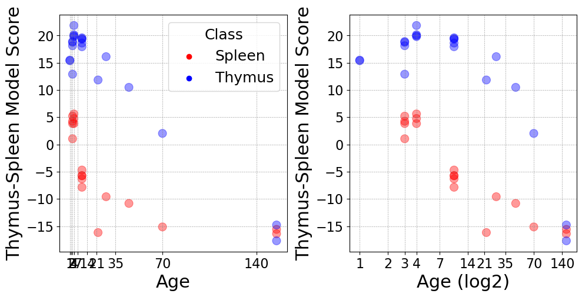

```python
#Import Independent Test Data

base_export_dir = 'Continious_Score_Model_Results'
os.makedirs(base_export_dir, exist_ok=True)

all_images = np.load('test_data/sample_images.npy')
all_labels = np.load('test_data/sample_labels.npy')
age_data = pd.read_csv('test_data/sampledef_age.csv')
timer_pos_data = pd.read_csv('test_data/timer_pos.csv')
timer_pos_data = timer_pos_data['timer_positive'].values
all_ages = age_data['age'].values
all_timers_scaled = timer_pos_data/100
age_scaled = log_scale_age(age_data['age'], 400)

new_labels = []
for i in range(len(all_labels)):
    organ = "Spleen" if all_labels[i,0] == 1 else "Thymus"

    new_labels.append(organ)

new_labels = np.array(new_labels)

encoder = LabelEncoder()
integer_labels = encoder.fit_transform(new_labels)
one_hot_labels = to_categorical(integer_labels, num_classes=2)
class_indices = {class_name: np.where(integer_labels == i)[0] for i, class_name in enumerate(encoder.classes_)}

age_scaled = age_scaled.values.reshape(-1, 1)
all_timers_scaled = all_timers_scaled.reshape(-1, 1)
spleen_indices = np.where(all_labels[:, 0] == 1)[0]
thymus_indices = np.where(all_labels[:, 0] == 0)[0]
spleen_images = all_images[spleen_indices]
thymus_images = all_images[thymus_indices]

spleen_labels = all_labels[spleen_indices]
thymus_labels = all_labels[thymus_indices]

age_vec = age_data['age']
age_data_spleen = age_vec[spleen_indices]
age_data_thymus = age_vec[thymus_indices]


continuous_scores = continuous_score_model.predict([all_images, age_scaled, all_timers_scaled])

continuous_scores = np.array(continuous_scores[:,0]).flatten() * (-1)
spleen_scores = continuous_scores[spleen_indices]
thymus_scores = continuous_scores[thymus_indices]

spleen_scores = np.array(spleen_scores).flatten()
thymus_scores = np.array(thymus_scores).flatten()
# --- Data Preparation ---
df_spleen = pd.DataFrame({
    'Age': age_data_spleen,
    'Score': spleen_scores,
    'Class': 'Spleen'
})
df_thymus = pd.DataFrame({
    'Age': age_data_thymus,
    'Score': thymus_scores,
    'Class': 'Thymus'
})

df_combined = pd.concat([df_spleen, df_thymus], ignore_index=True)
df_combined['Logged Age'] = np.log2(df_combined['Age'])

# --- Plotting Setup ---
fig, axes = plt.subplots(1, 2, figsize=(10, 5), sharey=False)
label_font = 22
title_font = 22

# Use all existing ages for vertical grid lines
unique_ages = np.array([1,2, 3,4, 7, 14, 21, 35,70,140 ])#np.unique(df_combined['Age'])
logged_unique_ages = np.log2(unique_ages)

# Panel 0: Original Age vs Score
sns.scatterplot(
    data=df_combined, x='Age', y='Score', hue='Class',
    palette={'Spleen': 'red', 'Thymus': 'blue'},
    alpha=0.4, edgecolor=None, ax=axes[0], s=100
)
axes[0].set_xlabel("Age", fontsize=label_font)
axes[0].set_ylabel("Thymus-Spleen Model Score", fontsize=label_font)
axes[0].legend(title='Class', fontsize=18, title_fontsize=18, loc='upper right')
axes[0].set_xticks(unique_ages)
axes[0].grid(True, which='both', linestyle='--', linewidth=0.5, color='gray', alpha=0.7)
axes[0].tick_params(axis='y', labelsize=16)
axes[0].tick_params(axis='x', labelsize=16)

# Panel 2: Logged Age vs Score (Custom Ticks)
sns.scatterplot(
    data=df_combined, x='Logged Age', y='Score', hue='Class',
    palette={'Spleen': 'red', 'Thymus': 'blue'},
    alpha=0.4, edgecolor=None, ax=axes[1], s=100,
    legend=False
)
axes[1].set_xlabel("Age (log2)", fontsize=label_font)
axes[1].set_ylabel("Thymus-Spleen Model Score", fontsize=label_font)
axes[1].set_xticks(logged_unique_ages)
axes[1].set_xticklabels(unique_ages.astype(int), fontsize = 16)
axes[1].tick_params(axis='y', labelsize=16)  # Set the font size for y-tick labels to 16
axes[1].grid(True, which='both', linestyle='--', linewidth=0.5, color='gray', alpha=0.7)

plt.tight_layout()

os.makedirs(base_export_dir, exist_ok=True)
pdf_path = os.path.join(base_export_dir, 'TestData_class_plot.pdf')
with PdfPages(pdf_path) as pdf:
    pdf.savefig(fig)
print(f"Saved the combined plot to {pdf_path}")

csv_path = os.path.join(base_export_dir, 'TestData_class_plot.csv')
df_combined.to_csv(csv_path, index=False)
print(f"Saved the combined DataFrame to {csv_path}")

plt.show()
```

```
Saved the combined plot to Continious_Score_Model_Results/TestData_class_plot_with_regression.pdf
Saved the combined DataFrame to Continious_Score_Model_Results/TestData_class_plot_with_regression.csv
```

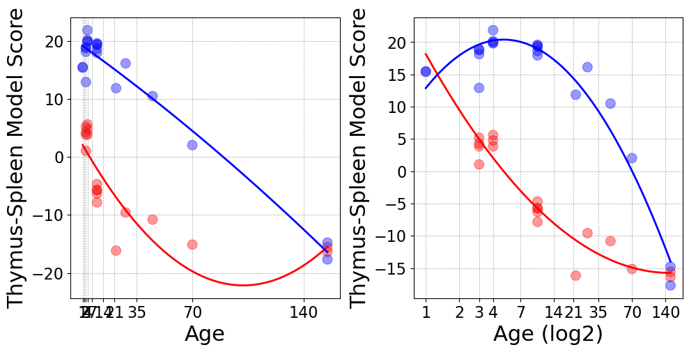

```python
# Regression
# Compute continuous scores
continuous_scores = continuous_score_model.predict([all_images, age_scaled, all_timers_scaled])
continuous_scores = np.array(continuous_scores[:, 0]).flatten() * (-1)
spleen_scores = continuous_scores[spleen_indices]
thymus_scores = continuous_scores[thymus_indices]
spleen_scores = np.array(spleen_scores).flatten()
thymus_scores = np.array(thymus_scores).flatten()

# --- Data Preparation ---
df_spleen = pd.DataFrame({
    'Age': age_data_spleen,
    'Score': spleen_scores,
    'Class': 'Spleen'
})
df_thymus = pd.DataFrame({
    'Age': age_data_thymus,
    'Score': thymus_scores,
    'Class': 'Thymus'
})
df_combined = pd.concat([df_spleen, df_thymus], ignore_index=True)
df_combined['Logged Age'] = np.log2(df_combined['Age'])

# --- Quadratic Regression Setup ---
def fit_quadratic_model(X, y):
    model = Pipeline([
        ('poly', PolynomialFeatures(degree=2)),
        ('linear', LinearRegression())
    ])
    model.fit(X, y)
    return model

min_age, max_age = df_combined['Age'].min(), df_combined['Age'].max()
min_logged, max_logged = df_combined['Logged Age'].min(), df_combined['Logged Age'].max()

age_grid = np.linspace(min_age, max_age, 100).reshape(-1, 1)
logged_age_grid = np.linspace(min_logged, max_logged, 100).reshape(-1, 1)

age_grid_df = pd.DataFrame(age_grid, columns=['Age'])
logged_age_grid_df = pd.DataFrame(logged_age_grid, columns=['Logged Age'])

models_age = {}
models_logged = {}
for cl in ['Spleen', 'Thymus']:
    df_cl = df_combined[df_combined['Class'] == cl]
    models_age[cl] = fit_quadratic_model(df_cl[['Age']], df_cl['Score'])
    models_logged[cl] = fit_quadratic_model(df_cl[['Logged Age']], df_cl['Score'])

predictions_age = {cl: models_age[cl].predict(age_grid_df) for cl in ['Spleen', 'Thymus']}
predictions_logged = {cl: models_logged[cl].predict(logged_age_grid_df) for cl in ['Spleen', 'Thymus']}


fig, axes = plt.subplots(1, 2, figsize=(10, 5), sharey=False)
label_font = 22

unique_ages = np.array([1, 2, 3, 4, 7, 14, 21, 35, 70, 140])
logged_unique_ages = np.log2(unique_ages)

# Panel 0: Raw Age vs Score with Quadratic Regression Lines
sns.scatterplot(
    data=df_combined, x='Age', y='Score', hue='Class',
    palette={'Spleen': 'red', 'Thymus': 'blue'},
    alpha=0.4, edgecolor=None, ax=axes[0], s=100, legend = None
)
for cl, color in zip(['Spleen', 'Thymus'], ['red', 'blue']):
    axes[0].plot(age_grid, predictions_age[cl], color=color, lw=2, label=f'{cl} Quad Fit')
axes[0].set_xlabel("Age", fontsize=label_font)
axes[0].set_ylabel("Thymus-Spleen Model Score", fontsize=label_font)
axes[0].set_xticks(unique_ages)
axes[0].grid(True, which='both', linestyle='--', linewidth=0.5, color='gray', alpha=0.7)
axes[0].tick_params(axis='x', labelsize=16)
axes[0].tick_params(axis='y', labelsize=16)

# Panel 1: Logged Age vs Score with Quadratic Regression Lines
sns.scatterplot(
    data=df_combined, x='Logged Age', y='Score', hue='Class',
    palette={'Spleen': 'red', 'Thymus': 'blue'},
    alpha=0.4, edgecolor=None, ax=axes[1], s=100,
    legend=False
)
for cl, color in zip(['Spleen', 'Thymus'], ['red', 'blue']):
    axes[1].plot(logged_age_grid, predictions_logged[cl], color=color, lw=2)
axes[1].set_ylabel("Thymus-Spleen Model Score", fontsize=label_font)
axes[1].set_xlabel("Age (log2)", fontsize=label_font)
axes[1].set_xticks(logged_unique_ages)
axes[1].set_xticklabels(unique_ages.astype(int), fontsize=16)
axes[1].grid(True, which='both', linestyle='--', linewidth=0.5, color='gray', alpha=0.7)
axes[1].tick_params(axis='y', labelsize=16)

plt.tight_layout()


os.makedirs(base_export_dir, exist_ok=True)
pdf_path = os.path.join(base_export_dir, 'TestData_class_plot_with_regression.pdf')
with PdfPages(pdf_path) as pdf:
    pdf.savefig(fig)
print(f"Saved the combined plot to {pdf_path}")

csv_path = os.path.join(base_export_dir, 'TestData_class_plot_with_regression.csv')
df_combined.to_csv(csv_path, index=False)
print(f"Saved the combined DataFrame to {csv_path}")

# --- Model Parameters Export ---
parameters = []
for model_type, model_dict, col_name in [('Age', models_age, 'Age'), ('Logged Age', models_logged, 'Logged Age')]:
    for cl, model in model_dict.items():
        poly = model.named_steps['poly']
        linear = model.named_steps['linear']
        feature_names = poly.get_feature_names_out([col_name])
        intercept = linear.intercept_
        parameters.append({
            'Class': cl,
            'Model_Type': model_type,
            'Feature': 'Intercept',
            'Coefficient': intercept
        })
        for fname, coef in zip(feature_names, linear.coef_):
            parameters.append({
                'Class': cl,
                'Model_Type': model_type,
                'Feature': fname,
                'Coefficient': coef
            })


params_df = pd.DataFrame(parameters)
params_csv_path = os.path.join(base_export_dir, 'quadratic_model_parameters.csv')
params_df.to_csv(params_csv_path, index=False)


plt.show()
```

```python
# Thymus Data vs Age
X = sm.add_constant(np.column_stack((df_thymus['Age'], df_thymus['Age']**2)))
y = df_thymus['Score']

q_model = sm.OLS(y, X).fit()
print(q_model.summary())
```

```
                            OLS Regression Results
==============================================================================
Dep. Variable:                  Score   R-squared:                       0.949
Model:                            OLS   Adj. R-squared:                  0.943
Method:                 Least Squares   F-statistic:                     167.4
Date:                Sun, 16 Feb 2025   Prob (F-statistic):           2.34e-12
Time:                        16:34:44   Log-Likelihood:                -48.107
No. Observations:                  21   AIC:                             102.2
Df Residuals:                      18   BIC:                             105.3
Df Model:                           2
Covariance Type:            nonrobust
==============================================================================
                 coef    std err          t      P>|t|      [0.025      0.975]
------------------------------------------------------------------------------
const         19.3294      0.803     24.061      0.000      17.642      21.017
x1            -0.1965      0.055     -3.548      0.002      -0.313      -0.080
x2            -0.0002      0.000     -0.621      0.542      -0.001       0.001
==============================================================================
Omnibus:                        3.509   Durbin-Watson:                   1.581
Prob(Omnibus):                  0.173   Jarque-Bera (JB):                2.678
Skew:                          -0.866   Prob(JB):                        0.262
Kurtosis:                       2.759   Cond. No.                     1.07e+04
==============================================================================

Notes:
[1] Standard Errors assume that the covariance matrix of the errors is correctly specified.
[2] The condition number is large, 1.07e+04. This might indicate that there are
strong multicollinearity or other numerical problems.
```

```python
# Thymus Data vs Log2(Age)
df_thymus['Logged Age'] = np.log2(df_thymus['Age'])
X = sm.add_constant(np.column_stack((df_thymus['Logged Age'], df_thymus['Logged Age']**2)))
y = df_thymus['Score']

q_model = sm.OLS(y, X).fit()

print(q_model.summary())
```

```
                            OLS Regression Results
==============================================================================
Dep. Variable:                  Score   R-squared:                       0.946
Model:                            OLS   Adj. R-squared:                  0.940
Method:                 Least Squares   F-statistic:                     158.8
Date:                Sun, 16 Feb 2025   Prob (F-statistic):           3.68e-12
Time:                        16:34:44   Log-Likelihood:                -48.634
No. Observations:                  21   AIC:                             103.3
Df Residuals:                      18   BIC:                             106.4
Df Model:                           2
Covariance Type:            nonrobust
==============================================================================
                 coef    std err          t      P>|t|      [0.025      0.975]
------------------------------------------------------------------------------
const         12.8814      1.592      8.093      0.000       9.537      16.225
x1             6.4773      0.982      6.597      0.000       4.415       8.540
x2            -1.3974      0.126    -11.080      0.000      -1.662      -1.132
==============================================================================
Omnibus:                        3.893   Durbin-Watson:                   1.817
Prob(Omnibus):                  0.143   Jarque-Bera (JB):                1.943
Skew:                          -0.540   Prob(JB):                        0.378
Kurtosis:                       4.026   Cond. No.                         68.4
==============================================================================

Notes:
[1] Standard Errors assume that the covariance matrix of the errors is correctly specified.
```

```python
# Spleen Data vs Age

X = sm.add_constant(np.column_stack((df_spleen['Age'], df_spleen['Age']**2)))
y = df_spleen['Score']

q_model = sm.OLS(y, X).fit()

print(q_model.summary())
```

```
                            OLS Regression Results
==============================================================================
Dep. Variable:                  Score   R-squared:                       0.741
Model:                            OLS   Adj. R-squared:                  0.706
Method:                 Least Squares   F-statistic:                     21.45
Date:                Sun, 16 Feb 2025   Prob (F-statistic):           3.99e-05
Time:                        16:37:51   Log-Likelihood:                -50.595
No. Observations:                  18   AIC:                             107.2
Df Residuals:                      15   BIC:                             109.9
Df Model:                           2
Covariance Type:            nonrobust
==============================================================================
                 coef    std err          t      P>|t|      [0.025      0.975]
------------------------------------------------------------------------------
const          2.5364      1.575      1.611      0.128      -0.820       5.892
x1            -0.4839      0.099     -4.864      0.000      -0.696      -0.272
x2             0.0024      0.001      3.773      0.002       0.001       0.004
==============================================================================
Omnibus:                        1.533   Durbin-Watson:                   0.712
Prob(Omnibus):                  0.465   Jarque-Bera (JB):                1.296
Skew:                          -0.570   Prob(JB):                        0.523
Kurtosis:                       2.346   Cond. No.                     1.23e+04
==============================================================================

Notes:
[1] Standard Errors assume that the covariance matrix of the errors is correctly specified.
[2] The condition number is large, 1.23e+04. This might indicate that there are
strong multicollinearity or other numerical problems.
```

```python
# Spleen Data vs Log2(Age)
df_spleen['Logged Age'] = np.log2(df_spleen['Age'])
X = sm.add_constant(np.column_stack((df_spleen['Logged Age'], df_spleen['Logged Age']**2)))
y = df_spleen['Score']

q_model = sm.OLS(y, X).fit()

print(q_model.summary())
```

```
                            OLS Regression Results
==============================================================================
Dep. Variable:                  Score   R-squared:                       0.920
Model:                            OLS   Adj. R-squared:                  0.909
Method:                 Least Squares   F-statistic:                     85.89
Date:                Sun, 16 Feb 2025   Prob (F-statistic):           6.10e-09
Time:                        16:38:00   Log-Likelihood:                -40.053
No. Observations:                  18   AIC:                             86.11
Df Residuals:                      15   BIC:                             88.78
Df Model:                           2
Covariance Type:            nonrobust
==============================================================================
                 coef    std err          t      P>|t|      [0.025      0.975]
------------------------------------------------------------------------------
const         18.1497      2.847      6.376      0.000      12.082      24.217
x1            -9.3239      1.581     -5.898      0.000     -12.693      -5.954
x2             0.6413      0.183      3.506      0.003       0.251       1.031
==============================================================================
Omnibus:                        2.639   Durbin-Watson:                   1.908
Prob(Omnibus):                  0.267   Jarque-Bera (JB):                1.270
Skew:                          -0.636   Prob(JB):                        0.530
Kurtosis:                       3.273   Cond. No.                         131.
==============================================================================

Notes:
[1] Standard Errors assume that the covariance matrix of the errors is correctly specified.
```

```python
continuous_score_model.save('Foxp3DevAge_Logit.keras')
```

```
WARNING:tensorflow:Compiled the loaded model, but the compiled metrics have yet to be built. `model.compile_metrics` will be empty until you train or evaluate the model.
```